# Kaplan-Meier

Zhuoyan Guo

2024-12-03

```r
library(readr)
library(dplyr)
library(survival)
```

```r
library(ggplot2)
library(survminer)
data <- read_csv("../data/raw-data/aids_clinical_trials_combined.csv", show_col_types = FALSE)
```

```r
str(data)
```

```
## spc_tbl_ [2,139 × 24] (S3: spec_tbl_df/tbl_df/tbl/data.frame)
##  $ time   : num [1:2139] 948 1002 961 1166 1090 ...
##  $ trt    : num [1:2139] 2 3 3 3 0 1 0 0 3 0 ...
##  $ age    : num [1:2139] 48 61 45 47 43 46 31 41 40 35 ...
##  $ wtkg   : num [1:2139] 89.8 49.4 88.5 85.3 66.7 ...
##  $ hemo   : num [1:2139] 0 0 0 0 0 0 0 0 0 0 ...
##  $ homo   : num [1:2139] 0 0 1 1 1 1 1 1 1 1 ...
##  $ drugs  : num [1:2139] 0 0 1 0 0 1 0 1 0 0 ...
##  $ karnof : num [1:2139] 100 90 90 100 100 100 100 100 90 100 ...
##  $ oprior : num [1:2139] 0 0 0 0 0 0 0 0 0 0 ...
##  $ z30    : num [1:2139] 0 1 1 1 1 1 1 1 1 1 ...
##  $ zprior : num [1:2139] 1 1 1 1 1 1 1 1 1 1 ...
##  $ preanti: num [1:2139] 0 895 707 1399 1352 ...
##  $ race   : num [1:2139] 0 0 0 0 0 0 0 0 0 0 ...
##  $ gender : num [1:2139] 0 0 1 1 1 1 1 1 1 1 ...
##  $ str2   : num [1:2139] 0 1 1 1 1 1 1 1 1 1 ...
##  $ strat  : num [1:2139] 1 3 3 3 3 3 3 3 3 3 ...
##  $ symptom: num [1:2139] 0 0 0 0 0 0 0 0 1 0 ...
##  $ treat  : num [1:2139] 1 1 1 1 0 1 0 0 1 0 ...
##  $ offtrt : num [1:2139] 0 0 1 0 0 0 0 0 1 1 ...
##  $ cd40   : num [1:2139] 422 162 326 287 504 235 244 401 214 221 ...
##  $ cd420  : num [1:2139] 477 218 274 394 353 339 225 366 107 132 ...
##  $ cd80   : num [1:2139] 566 392 2063 1590 870 ...
##  $ cd820  : num [1:2139] 324 564 1893 966 782 ...
##  $ cid    : num [1:2139] 0 1 0 0 0 0 1 0 1 1 ...
##  - attr(*, "spec")=
##   .. cols(
##   ..   time = col_double(),
##   ..   trt = col_double(),
##   ..   age = col_double(),
##   ..   wtkg = col_double(),
##   ..   hemo = col_double(),
##   ..   homo = col_double(),
##   ..   drugs = col_double(),
##   ..   karnof = col_double(),
##   ..   oprior = col_double(),
##   ..   z30 = col_double(),
##   ..   zprior = col_double(),
##   ..   preanti = col_double(),
##   ..   race = col_double(),
##   ..   gender = col_double(),
##   ..   str2 = col_double(),
##   ..   strat = col_double(),
##   ..   symptom = col_double(),
##   ..   treat = col_double(),
##   ..   offtrt = col_double(),
##   ..   cd40 = col_double(),
##   ..   cd420 = col_double(),
##   ..   cd80 = col_double(),
##   ..   cd820 = col_double(),
##   ..   cid = col_double()
##   .. )
##  - attr(*, "problems")=<externalptr>
```

```r
summary(data)
```

```
##       time             trt             age             wtkg
##  Min.   :  14.0   Min.   :0.000   Min.   :12.00   Min.   : 31.00
##  1st Qu.: 727.0   1st Qu.:1.000   1st Qu.:29.00   1st Qu.: 66.68
##  Median : 997.0   Median :2.000   Median :34.00   Median : 74.39
##  Mean   : 879.1   Mean   :1.521   Mean   :35.25   Mean   : 75.13
##  3rd Qu.:1091.0   3rd Qu.:3.000   3rd Qu.:40.00   3rd Qu.: 82.56
##  Max.   :1231.0   Max.   :3.000   Max.   :70.00   Max.   :159.94
##       hemo              homo            drugs            karnof
##  Min.   :0.00000   Min.   :0.0000   Min.   :0.0000   Min.   : 70.00
##  1st Qu.:0.00000   1st Qu.:0.0000   1st Qu.:0.0000   1st Qu.: 90.00
##  Median :0.00000   Median :1.0000   Median :0.0000   Median :100.00
##  Mean   :0.08415   Mean   :0.6611   Mean   :0.1314   Mean   : 95.45
##  3rd Qu.:0.00000   3rd Qu.:1.0000   3rd Qu.:0.0000   3rd Qu.:100.00
##  Max.   :1.00000   Max.   :1.0000   Max.   :1.0000   Max.   :100.00
##      oprior             z30             zprior     preanti
##  Min.   :0.00000   Min.   :0.0000   Min.   :1   Min.   :   0.0
##  1st Qu.:0.00000   1st Qu.:0.0000   1st Qu.:1   1st Qu.:   0.0
##  Median :0.00000   Median :1.0000   Median :1   Median : 142.0
##  Mean   :0.02197   Mean   :0.5503   Mean   :1   Mean   : 379.2
##  3rd Qu.:0.00000   3rd Qu.:1.0000   3rd Qu.:1   3rd Qu.: 739.5
##  Max.   :1.00000   Max.   :1.0000   Max.   :1   Max.   :2851.0
##       race            gender           str2            strat
##  Min.   :0.0000   Min.   :0.000   Min.   :0.0000   Min.   :1.00
##  1st Qu.:0.0000   1st Qu.:1.000   1st Qu.:0.0000   1st Qu.:1.00
##  Median :0.0000   Median :1.000   Median :1.0000   Median :2.00
##  Mean   :0.2885   Mean   :0.828   Mean   :0.5858   Mean   :1.98
##  3rd Qu.:1.0000   3rd Qu.:1.000   3rd Qu.:1.0000   3rd Qu.:3.00
##  Max.   :1.0000   Max.   :1.000   Max.   :1.0000   Max.   :3.00
##     symptom          treat            offtrt            cd40
##  Min.   :0.000   Min.   :0.0000   Min.   :0.0000   Min.   :   0.0
##  1st Qu.:0.000   1st Qu.:1.0000   1st Qu.:0.0000   1st Qu.: 263.5
##  Median :0.000   Median :1.0000   Median :0.0000   Median : 340.0
##  Mean   :0.173   Mean   :0.7513   Mean   :0.3628   Mean   : 350.5
##  3rd Qu.:0.000   3rd Qu.:1.0000   3rd Qu.:1.0000   3rd Qu.: 423.0
##  Max.   :1.000   Max.   :1.0000   Max.   :1.0000   Max.   :1199.0
##      cd420             cd80            cd820             cid
##  Min.   :  49.0   Min.   :  40.0   Min.   : 124.0   Min.   :0.0000
##  1st Qu.: 269.0   1st Qu.: 654.0   1st Qu.: 631.5   1st Qu.:0.0000
##  Median : 353.0   Median : 893.0   Median : 865.0   Median :0.0000
##  Mean   : 371.3   Mean   : 986.6   Mean   : 935.4   Mean   :0.2436
##  3rd Qu.: 460.0   3rd Qu.:1207.0   3rd Qu.:1146.5   3rd Qu.:0.0000
##  Max.   :1119.0   Max.   :5011.0   Max.   :6035.0   Max.   :1.0000
```

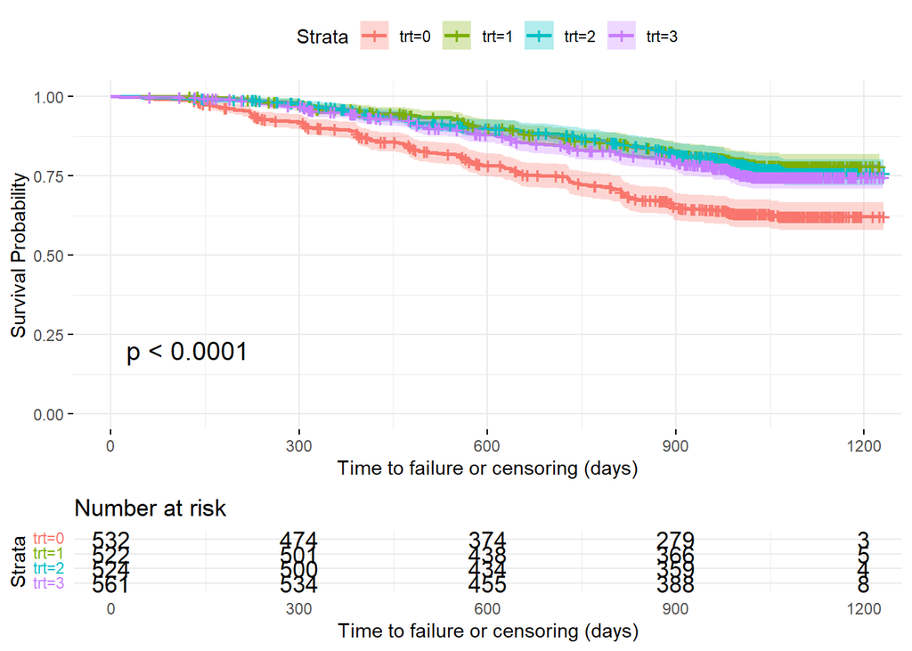

```r
surv_object <- Surv(time = data$time, event = data$cid)
km_fit <- survfit(surv_object ~ trt, data = data)

# Plot Kaplan-Meier survival curves
ggsurvplot(km_fit, data = data, risk.table = TRUE, pval = TRUE,
           conf.int = TRUE, xlab = "Time to failure or censoring (days)",
           ylab = "Survival Probability", ggtheme = theme_minimal())
```

The p-value (p < 0.0001) indicates that there is a statistically significant difference between the survival curves of the different treatment groups. This means that the treatment has a significant effect on survival outcomes. trt=0 perform worst and trt=1 seems perform best compared to others.

## Creating a New Kaplan-Meier Curve for trt=1, trt=2, trt=3

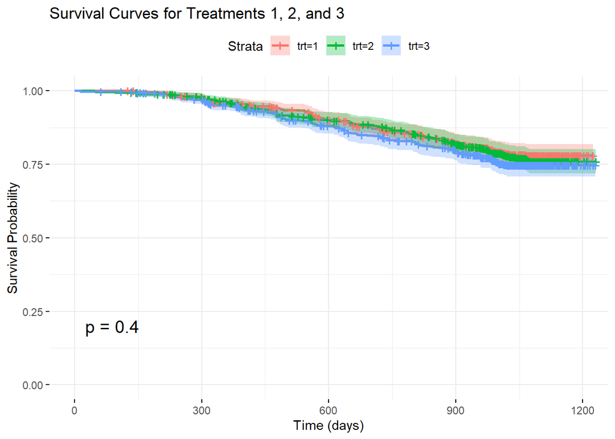

```r
# Subset the data to exclude treatment 0
data_subset <- subset(data, trt %in% c(1, 2, 3))

# Ensure the treatment variable is still treated as a factor with the correct levels
data_subset$trt <- factor(data_subset$trt, levels = c(1, 2, 3))

# Fit the Kaplan-Meier survival model
fit_subset <- survfit(Surv(time, cid) ~ trt, data = data_subset)

# Plot the survival curves using ggsurvplot
plot_subset <- ggsurvplot(
    fit_subset,
    data = data_subset,
    pval = TRUE,
    conf.int = TRUE,
    xlab = "Time (days)",
    ylab = "Survival Probability",
    ggtheme = theme_minimal(),
    title = "Survival Curves for Treatments 1, 2, and 3"
)

# Print the plot
print(plot_subset)
```

By creating a new Kaplan-Meier survival curve that includes only treatments 1, 2, and 3, with the p-value = 0.4, we cannot conclude that there are significant differences in survival rates among the different treatment groups trt=1, trt=2, trt=3.

## Stratified Kaplan-Meier Curves – Treatment and Gender

```r
# Step 1: Required libraries
library(survival)
library(survminer)
library(gridExtra)
```

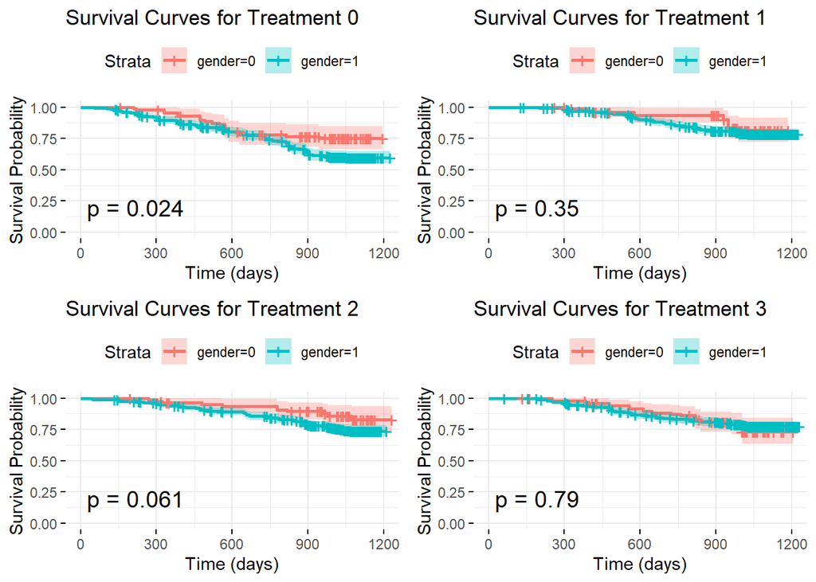

```r
library(dplyr)

# Step 2: Bootstrap function
perform_bootstrap <- function(data, n_bootstrap = 100) {
  # Create list to store bootstrap samples
  boot_samples <- list()

  for(i in 1:n_bootstrap) {
    # Sample with replacement, stratified by treatment
    boot_sample <- data %>%
      group_by(trt) %>%
      slice_sample(prop = 1, replace = TRUE) %>%
      ungroup()

    boot_samples[[i]] <- boot_sample
  }

  return(boot_samples)
}

# Step 3: Function to create survival plots for one bootstrap sample
create_survival_plots <- function(boot_data) {
  plots <- list()

  for(t in levels(boot_data$trt)) {
    trt_data <- boot_data[boot_data$trt == t,]
    if(nrow(trt_data) > 0) {
      fit <- survfit(Surv(time, cid) ~ gender, data = trt_data)
      plot <- ggsurvplot(
        fit,
        data = trt_data,
        pval = TRUE,
        conf.int = TRUE,
        xlab = "Time (days)",
        ylab = "Survival Probability",
        ggtheme = theme_minimal(),
        title = sprintf("Survival Curves for Treatment %s", t)
      )
      plots[[as.character(t)]] <- plot$plot
    }
  }

  return(plots)
}

# Step 4: Perform bootstrap
set.seed(123) # for reproducibility
data$trt <- factor(data$trt, levels = c(0, 1, 2, 3))
data$race <- as.factor(data$race)
boot_samples <- perform_bootstrap(data, n_bootstrap = 100)

# Step 5: Create plots for each bootstrap sample
# Let's look at the first bootstrap sample as an example
boot_plots <- create_survival_plots(boot_samples[[1]])

# Display the plots for the first bootstrap sample
do.call(grid.arrange, c(boot_plots, ncol = 2, nrow = 2))
```

## Stratified Kaplan-Meier Curves – Treatment and Race

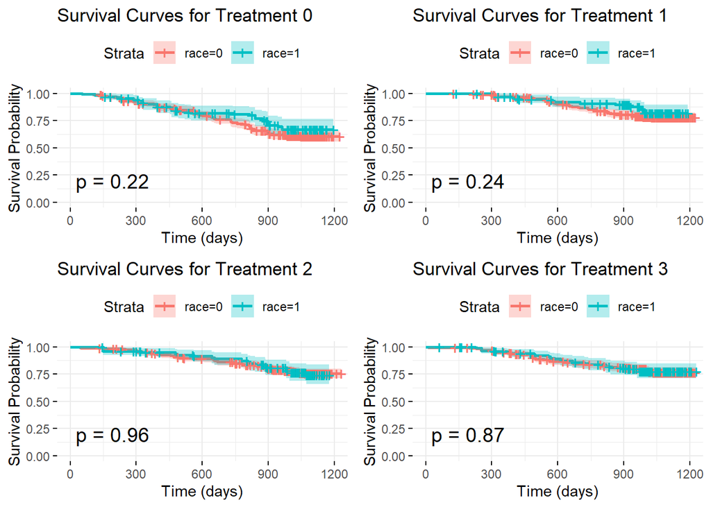

```r
# Step 1: Required libraries
library(survival)
library(survminer)
library(gridExtra)
library(dplyr)

# Step 2: Bootstrap function
perform_bootstrap <- function(data, n_bootstrap = 100) {
  # Create list to store bootstrap samples
  boot_samples <- list()

  for(i in 1:n_bootstrap) {
    # Sample with replacement, stratified by treatment
    boot_sample <- data %>%
      group_by(trt) %>%
      slice_sample(prop = 1, replace = TRUE) %>%
      ungroup()

    boot_samples[[i]] <- boot_sample
  }

  return(boot_samples)
}

# Step 3: Function to create survival plots for one bootstrap sample
create_survival_plots <- function(boot_data) {
  plots <- list()

  for(t in levels(boot_data$trt)) {
    trt_data <- boot_data[boot_data$trt == t,]
    if(nrow(trt_data) > 0) {
      fit <- survfit(Surv(time, cid) ~ race, data = trt_data)
      plot <- ggsurvplot(
        fit,
        data = trt_data,
        pval = TRUE,
        conf.int = TRUE,
        xlab = "Time (days)",
        ylab = "Survival Probability",
        ggtheme = theme_minimal(),
        title = sprintf("Survival Curves for Treatment %s", t)
      )
      plots[[as.character(t)]] <- plot$plot
    }
  }

  return(plots)
}

# Step 4: Perform bootstrap
set.seed(123) # for reproducibility
data$trt <- factor(data$trt, levels = c(0, 1, 2, 3))
data$race <- as.factor(data$race)
boot_samples <- perform_bootstrap(data, n_bootstrap = 100)

# Step 5: Create plots for each bootstrap sample
# Let's look at the first bootstrap sample as an example
boot_plots <- create_survival_plots(boot_samples[[1]])

# Display the plots for the first bootstrap sample
do.call(grid.arrange, c(boot_plots, ncol = 2, nrow = 2))
```

## Stratified Kaplan-Meier Curves – Treatment and ARV History

Stratifying by ARV history allows us to explore how prior exposure to antiretroviral therapy impacts survival outcomes.

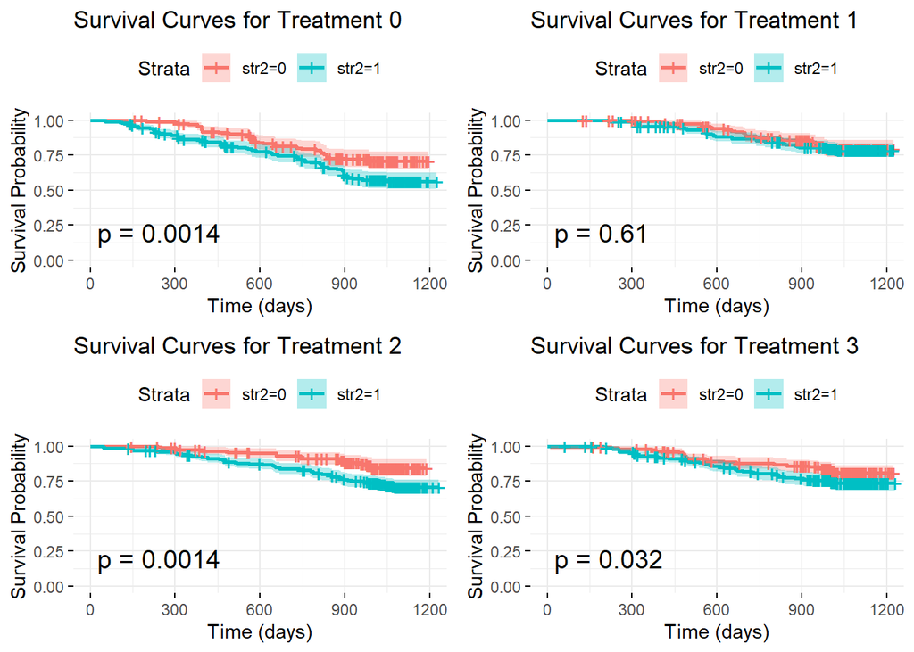

```r
# Step 1: Required libraries
library(survival)
library(survminer)
library(gridExtra)
library(dplyr)

# Step 2: Bootstrap function
perform_bootstrap <- function(data, n_bootstrap = 100) {
  # Create list to store bootstrap samples
  boot_samples <- list()

  for(i in 1:n_bootstrap) {
    # Sample with replacement, stratified by treatment
    boot_sample <- data %>%
      group_by(trt) %>%
      slice_sample(prop = 1, replace = TRUE) %>%
      ungroup()

    boot_samples[[i]] <- boot_sample
  }

  return(boot_samples)
}

# Step 3: Function to create survival plots for one bootstrap sample
create_survival_plots <- function(boot_data) {
  plots <- list()

  for(t in levels(boot_data$trt)) {
    trt_data <- boot_data[boot_data$trt == t,]
    if(nrow(trt_data) > 0) {
      fit <- survfit(Surv(time, cid) ~ str2, data = trt_data)
      plot <- ggsurvplot(
        fit,
        data = trt_data,
        pval = TRUE,
        conf.int = TRUE,
        xlab = "Time (days)",
        ylab = "Survival Probability",
        ggtheme = theme_minimal(),
        title = sprintf("Survival Curves for Treatment %s", t)
      )
      plots[[as.character(t)]] <- plot$plot
    }
  }

  return(plots)
}

# Step 4: Perform bootstrap
set.seed(123) # for reproducibility
data$trt <- factor(data$trt, levels = c(0, 1, 2, 3))
data$race <- as.factor(data$race)
boot_samples <- perform_bootstrap(data, n_bootstrap = 100)

# Step 5: Create plots for each bootstrap sample
# Let's look at the first bootstrap sample as an example
boot_plots <- create_survival_plots(boot_samples[[1]])

# Display the plots for the first bootstrap sample
do.call(grid.arrange, c(boot_plots, ncol = 2, nrow = 2))
```

Patients with prior ARV treatment might have developed drug resistance, reducing the effectiveness of subsequent treatments. However, using Treatment 1, antiretroviral history (naive vs. experienced) does not significantly impact survival outcomes for patients receiving Treatment 1. This means that previous exposure to antiretroviral therapy (ARV) does not appear to reduce the effectiveness of Treatment 1 in a statistically significant way.

## Stratified Kaplan-Meier Curves – Treatment and Symptom

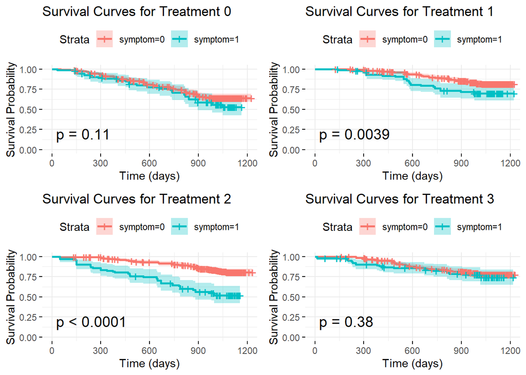

```r
# Step 1: Required libraries
library(survival)
library(survminer)
library(gridExtra)
library(dplyr)

# Step 2: Bootstrap function
perform_bootstrap <- function(data, n_bootstrap = 100) {
  # Create list to store bootstrap samples
  boot_samples <- list()

  for(i in 1:n_bootstrap) {
    # Sample with replacement, stratified by treatment
    boot_sample <- data %>%
      group_by(trt) %>%
      slice_sample(prop = 1, replace = TRUE) %>%
      ungroup()

    boot_samples[[i]] <- boot_sample
  }

  return(boot_samples)
}

# Step 3: Function to create survival plots for one bootstrap sample
create_survival_plots <- function(boot_data) {
  plots <- list()

  for(t in levels(boot_data$trt)) {
    trt_data <- boot_data[boot_data$trt == t,]
    if(nrow(trt_data) > 0) {
      fit <- survfit(Surv(time, cid) ~ symptom, data = trt_data)
      plot <- ggsurvplot(
        fit,
        data = trt_data,
        pval = TRUE,
        conf.int = TRUE,
        xlab = "Time (days)",
        ylab = "Survival Probability",
        ggtheme = theme_minimal(),
        title = sprintf("Survival Curves for Treatment %s", t)
      )
      plots[[as.character(t)]] <- plot$plot
    }
  }

  return(plots)
}

# Step 4: Perform bootstrap
set.seed(123) # for reproducibility
data$trt <- factor(data$trt, levels = c(0, 1, 2, 3))
data$race <- as.factor(data$race)
boot_samples <- perform_bootstrap(data, n_bootstrap = 100)

# Step 5: Create plots for each bootstrap sample
# Let's look at the first bootstrap sample as an example
boot_plots <- create_survival_plots(boot_samples[[1]])

# Display the plots for the first bootstrap sample
do.call(grid.arrange, c(boot_plots, ncol = 2, nrow = 2))
```

For Treatment 0 and 3, the p-values (0.11 and 0.38, respectively) indicate no statistically significant difference in survival probabilities between symptomatic and asymptomatic patients, suggesting that symptom status has no meaningful effect on survival in these treatment groups. However, for Treatment 1, the p-value (0.0039) shows a significant difference, where asymptomatic patients (symptom=0) exhibit slightly better survival probabilities compared to symptomatic patients (symptom=1). The most striking difference is observed in Treatment 2, where the p-value (<0.0001) and the clear divergence of the survival curves indicate a strong association between symptom status and survival, with asymptomatic patients (symptom=0) having markedly better survival outcomes.

## Stratified Kaplan-Meier Curves – Treatment and Homosexuality

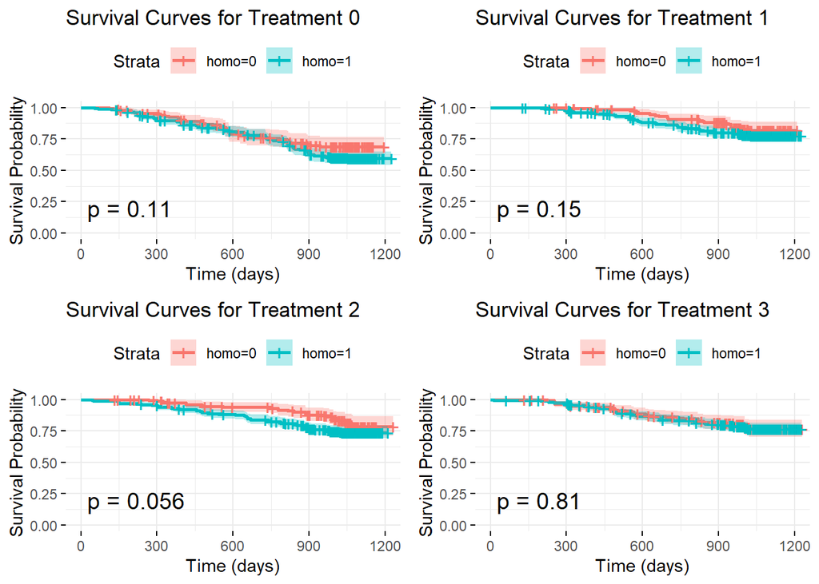

```r
# Step 1: Required libraries
library(survival)
library(survminer)
library(gridExtra)
library(dplyr)

# Step 2: Bootstrap function
perform_bootstrap <- function(data, n_bootstrap = 100) {
  # Create list to store bootstrap samples
  boot_samples <- list()

  for(i in 1:n_bootstrap) {
    # Sample with replacement, stratified by treatment
    boot_sample <- data %>%
      group_by(trt) %>%
      slice_sample(prop = 1, replace = TRUE) %>%
      ungroup()

    boot_samples[[i]] <- boot_sample
  }

  return(boot_samples)
}

# Step 3: Function to create survival plots for one bootstrap sample
create_survival_plots <- function(boot_data) {
  plots <- list()

  for(t in levels(boot_data$trt)) {
    trt_data <- boot_data[boot_data$trt == t,]
    if(nrow(trt_data) > 0) {
      fit <- survfit(Surv(time, cid) ~ homo, data = trt_data)
      plot <- ggsurvplot(
        fit,
        data = trt_data,
        pval = TRUE,
        conf.int = TRUE,
        xlab = "Time (days)",
        ylab = "Survival Probability",
        ggtheme = theme_minimal(),
        title = sprintf("Survival Curves for Treatment %s", t)
      )
      plots[[as.character(t)]] <- plot$plot
    }
  }

  return(plots)
}

# Step 4: Perform bootstrap
set.seed(123) # for reproducibility
data$trt <- factor(data$trt, levels = c(0, 1, 2, 3))
data$race <- as.factor(data$race)
boot_samples <- perform_bootstrap(data, n_bootstrap = 100)

# Step 5: Create plots for each bootstrap sample
# Let's look at the first bootstrap sample as an example
boot_plots <- create_survival_plots(boot_samples[[1]])

# Display the plots for the first bootstrap sample
do.call(grid.arrange, c(boot_plots, ncol = 2, nrow = 2))
```

## Survival Probability vs. Karnofsky score

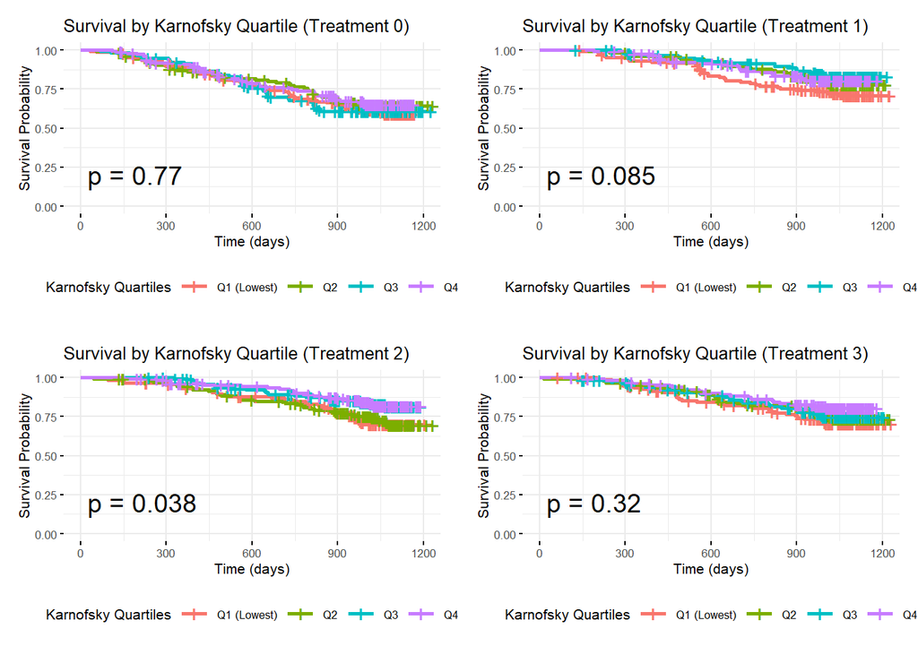

```r
# Create Karnofsky quartiles
data <- data %>%
  mutate(Karnofsky_quartile = ntile(karnof, 4))  # Assuming Karnofsky score column is 'karnof'

# Convert treatment to a factor if not already
data$trt <- factor(data$trt, levels = c(0, 1, 2, 3))

# Create a list to store the plots
plots <- list()

# Loop through each treatment and create separate Kaplan-Meier curves
for (t in levels(data$trt)) {
  # Subset data for the current treatment
  trt_data <- subset(data, trt == t)

  # Fit Kaplan-Meier survival curves for Karnofsky quartiles
  fit <- survfit(Surv(time, cid) ~ Karnofsky_quartile, data = trt_data)

  # Generate Kaplan-Meier plot
  plot <- ggsurvplot(
    fit,
    data = trt_data,
    pval = TRUE,
    conf.int = FALSE,  # Disable confidence intervals if they clutter the plot
    xlab = "Time (days)",
    ylab = "Survival Probability",
    legend.title = "Karnofsky Quartiles",  # Descriptive legend title
    legend.labs = c("Q1 (Lowest)", "Q2", "Q3", "Q4"),  # Adjust labels
    ggtheme = theme_minimal(base_size = 8),  # Larger base font size
    title = sprintf("Survival by Karnofsky Quartile (Treatment %s)", t),
    legend = "bottom"  # Position legend at the bottom
  )

  # Adjust plot margins for readability
  plot$plot <- plot$plot + theme(plot.margin = margin(10, 10, 10, 10))

  # Store the plot in the list
  plots[[t]] <- plot$plot
}

# Arrange the plots in a grid with better spacing
library(gridExtra)
do.call(grid.arrange, c(plots, ncol = 2, nrow = 2))
```

## Survival Probability vs. Age

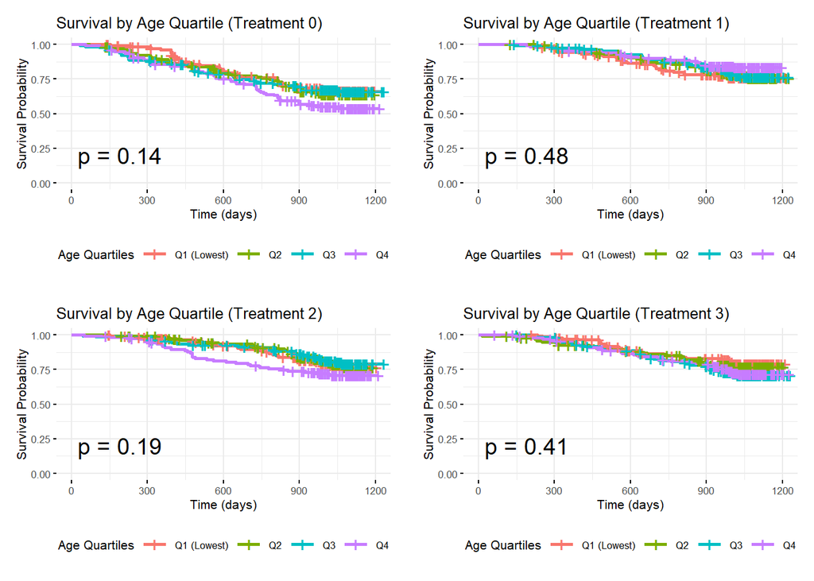

```r
# Create Karnofsky quartiles
data <- data %>%
  mutate(age_quartile = ntile(age, 4))

# Convert treatment to a factor if not already
data$trt <- factor(data$trt, levels = c(0, 1, 2, 3))

# Create a list to store the plots
plots <- list()

# Loop through each treatment and create separate Kaplan-Meier curves
for (t in levels(data$trt)) {
  # Subset data for the current treatment
  trt_data <- subset(data, trt == t)

  # Fit Kaplan-Meier survival curves for age quartiles
  fit <- survfit(Surv(time, cid) ~ age_quartile, data = trt_data)

  # Generate Kaplan-Meier plot
  plot <- ggsurvplot(
    fit,
    data = trt_data,
    pval = TRUE,
    conf.int = FALSE,  # Disable confidence intervals if they clutter the plot
    xlab = "Time (days)",
    ylab = "Survival Probability",
    legend.title = "Age Quartiles",  # Descriptive legend title
    legend.labs = c("Q1 (Lowest)", "Q2", "Q3", "Q4"),  # Adjust labels
    ggtheme = theme_minimal(base_size = 8),  # Larger base font size
    title = sprintf("Survival by Age Quartile (Treatment %s)", t),
    legend = "bottom"  # Position legend at the bottom
  )

  # Adjust plot margins for readability
  plot$plot <- plot$plot + theme(plot.margin = margin(10, 10, 10, 10))

  # Store the plot in the list
  plots[[t]] <- plot$plot
}

# Arrange the plots in a grid with better spacing
library(gridExtra)
do.call(grid.arrange, c(plots, ncol = 2, nrow = 2))
```

## Survival Probability vs. CD4 at baseline

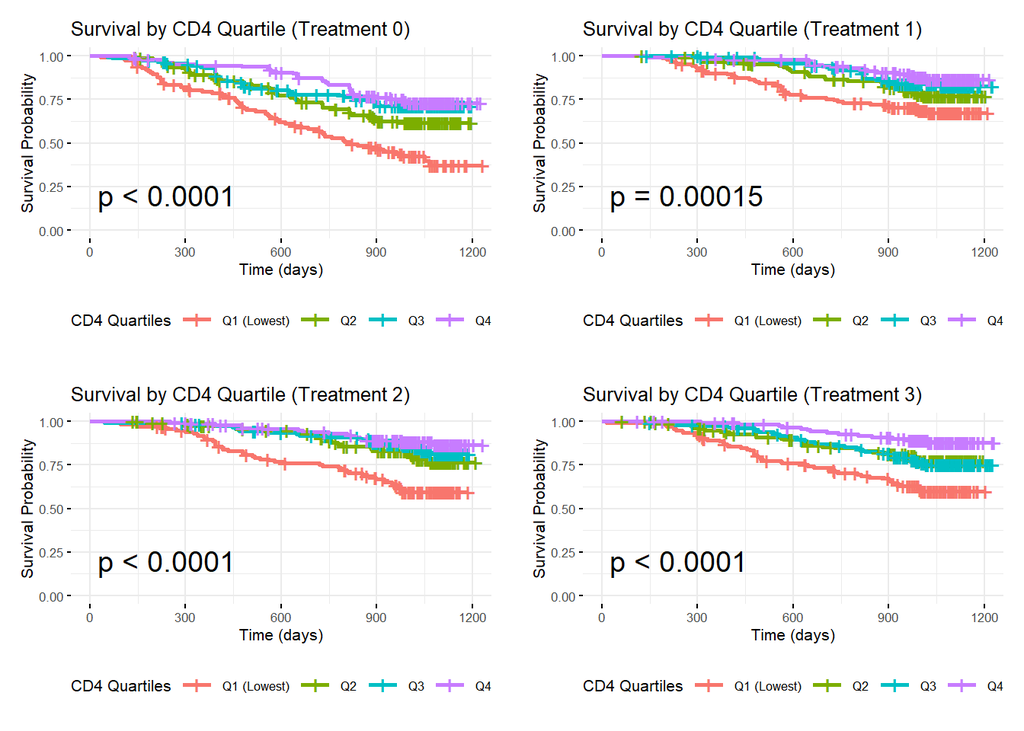

```r
# Create Karnofsky quartiles
data <- data %>%
  mutate(cd4_quartile = ntile(cd40, 4))

# Convert treatment to a factor if not already
data$trt <- factor(data$trt, levels = c(0, 1, 2, 3))

# Create a list to store the plots
plots <- list()

# Loop through each treatment and create separate Kaplan-Meier curves
for (t in levels(data$trt)) {
  # Subset data for the current treatment
  trt_data <- subset(data, trt == t)

  # Fit Kaplan-Meier survival curves for age quartiles
  fit <- survfit(Surv(time, cid) ~ cd4_quartile, data = trt_data)

  # Generate Kaplan-Meier plot
  plot <- ggsurvplot(
    fit,
    data = trt_data,
    pval = TRUE,
    conf.int = FALSE,  # Disable confidence intervals if they clutter the plot
    xlab = "Time (days)",
    ylab = "Survival Probability",
    legend.title = "CD4 Quartiles",  # Descriptive legend title
    legend.labs = c("Q1 (Lowest)", "Q2", "Q3", "Q4"),  # Adjust labels
    ggtheme = theme_minimal(base_size = 8),  # Larger base font size
    title = sprintf("Survival by CD4 Quartile (Treatment %s)", t),
    legend = "bottom"  # Position legend at the bottom
  )

  # Adjust plot margins for readability
  plot$plot <- plot$plot + theme(plot.margin = margin(10, 10, 10, 10))

  # Store the plot in the list
  plots[[t]] <- plot$plot
}

# Arrange the plots in a grid with better spacing
library(gridExtra)
do.call(grid.arrange, c(plots, ncol = 2, nrow = 2))
```

## Survival Probability vs. CD8 at baseline

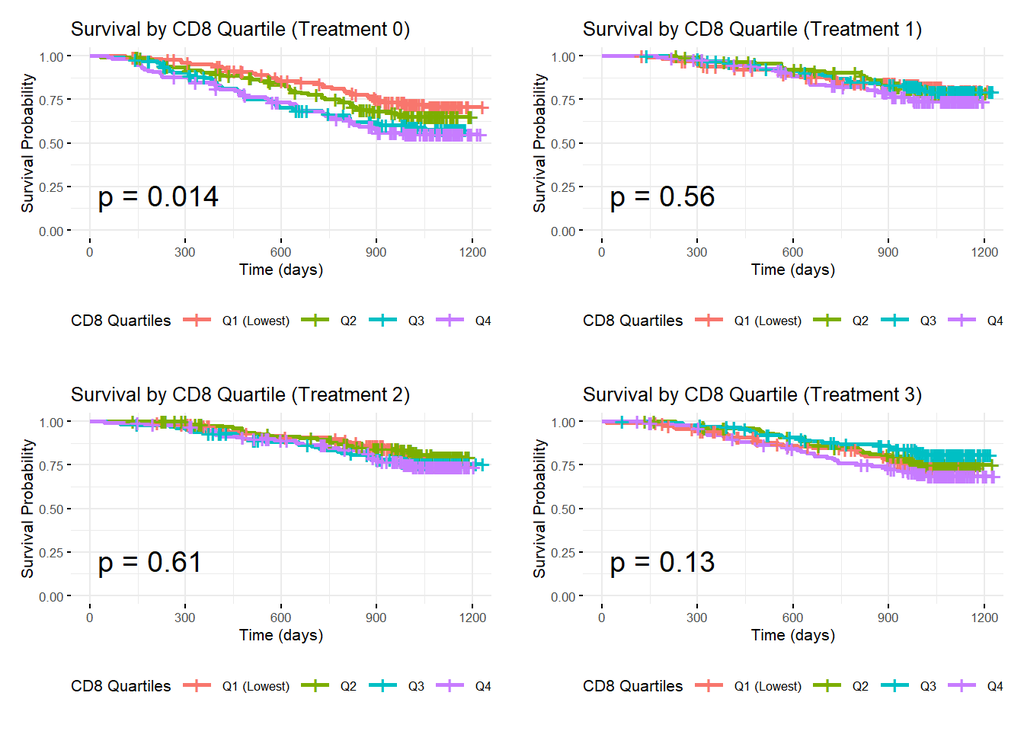

```r
# Create Karnofsky quartiles
data <- data %>%
  mutate(cd8_quartile = ntile(cd80, 4))

# Convert treatment to a factor if not already
data$trt <- factor(data$trt, levels = c(0, 1, 2, 3))

# Create a list to store the plots
plots <- list()

# Loop through each treatment and create separate Kaplan-Meier curves
for (t in levels(data$trt)) {
  # Subset data for the current treatment
  trt_data <- subset(data, trt == t)

  # Fit Kaplan-Meier survival curves for age quartiles
  fit <- survfit(Surv(time, cid) ~ cd8_quartile, data = trt_data)

  # Generate Kaplan-Meier plot
  plot <- ggsurvplot(
    fit,
    data = trt_data,
    pval = TRUE,
    conf.int = FALSE,  # Disable confidence intervals if they clutter the plot
    xlab = "Time (days)",
    ylab = "Survival Probability",
    legend.title = "CD8 Quartiles",  # Descriptive legend title
    legend.labs = c("Q1 (Lowest)", "Q2", "Q3", "Q4"),  # Adjust labels
    ggtheme = theme_minimal(base_size = 8),  # Larger base font size
    title = sprintf("Survival by CD8 Quartile (Treatment %s)", t),
    legend = "bottom"  # Position legend at the bottom
  )

  # Adjust plot margins for readability
  plot$plot <- plot$plot + theme(plot.margin = margin(10, 10, 10, 10))

  # Store the plot in the list
  plots[[t]] <- plot$plot
}

# Arrange the plots in a grid with better spacing
library(gridExtra)
do.call(grid.arrange, c(plots, ncol = 2, nrow = 2))
```

## Hazard

```r
data$trt <- as.factor(data$trt)
data$str2 <- as.factor(data$str2)
data$symptom <- as.factor(data$symptom)

# Build the Cox proportional hazards model
cox_model <- coxph(Surv(time, cid) ~ trt + karnof + str2 + symptom + cd40 +
                   trt:karnof + trt:str2 + trt:symptom + trt: cd40, data = data)

# Print the model summary to view hazard ratios and p-values
summary(cox_model)
```

```
## Call:
## coxph(formula = Surv(time, cid) ~ trt + karnof + str2 + symptom +
##     cd40 + trt:karnof + trt:str2 + trt:symptom + trt:cd40, data = data)
##
##   n= 2139, number of events= 521
##
##                     coef  exp(coef)   se(coef)      z Pr(>|z|)
## trt1           1.4057612  4.0786301  1.9758499  0.711   0.4768
## trt2           3.3183635 27.6151208  1.8513794  1.792   0.0731 .
## trt3           1.6457271  5.1847784  1.7695276  0.930   0.3524
## karnof        -0.0031986  0.9968065  0.0119526 -0.268   0.7890
## str21          0.3477516  1.4158805  0.1597284  2.177   0.0295 *
## symptom1       0.1560830  1.1689232  0.1874410  0.833   0.4050
## cd40          -0.0037680  0.9962391  0.0007590 -4.965 6.88e-07 ***
## trt1:karnof   -0.0266351  0.9737165  0.0200190 -1.330   0.1834
## trt2:karnof   -0.0458796  0.9551569  0.0193400 -2.372   0.0177 *
## trt3:karnof   -0.0224311  0.9778186  0.0181931 -1.233   0.2176
## trt1:str21    -0.1833573  0.8324706  0.2655192 -0.691   0.4898
## trt2:str21     0.4865993  1.6267746  0.2846289  1.710   0.0873 .
## trt3:str21    -0.1109591  0.8949754  0.2466556 -0.450   0.6528
## trt1:symptom1  0.4958563  1.6419036  0.2860848  1.733   0.0831 .
## trt2:symptom1  0.3173591  1.3734956  0.2875141  1.104   0.2697
## trt3:symptom1  0.4622027  1.5875670  0.2772970  1.667   0.0956 .
## trt1:cd40      0.0010875  1.0010881  0.0011689  0.930   0.3522
## trt2:cd40     -0.0003421  0.9996580  0.0012352 -0.277   0.7818
## trt3:cd40     -0.0003960  0.9996040  0.0011900 -0.333   0.7393
## ---
## Signif. codes:  0 '***' 0.001 '**' 0.01 '*' 0.05 '.' 0.1 ' ' 1
##
##               exp(coef) exp(-coef) lower .95 upper .95
## trt1             4.0786    0.24518   0.08485  196.0473
## trt2            27.6151    0.03621   0.73325 1040.0254
## trt3             5.1848    0.19287   0.16162  166.3240
## karnof           0.9968    1.00320   0.97373    1.0204
## str21            1.4159    0.70627   1.03530    1.9364
## symptom1         1.1689    0.85549   0.80954    1.6879
## cd40             0.9962    1.00378   0.99476    0.9977
## trt1:karnof      0.9737    1.02699   0.93625    1.0127
## trt2:karnof      0.9552    1.04695   0.91963    0.9921
## trt3:karnof      0.9778    1.02268   0.94357    1.0133
## trt1:str21       0.8325    1.20124   0.49472    1.4008
## trt2:str21       1.6268    0.61471   0.93122    2.8419
## trt3:str21       0.8950    1.11735   0.55190    1.4513
## trt1:symptom1    1.6419    0.60905   0.93720    2.8765
## trt2:symptom1    1.3735    0.72807   0.78180    2.4130
## trt3:symptom1    1.5876    0.62989   0.92193    2.7338
## trt1:cd40        1.0011    0.99891   0.99880    1.0034
## trt2:cd40        0.9997    1.00034   0.99724    1.0021
## trt3:cd40        0.9996    1.00040   0.99728    1.0019
##
## Concordance= 0.688  (se = 0.011 )
## Likelihood ratio test= 216.2  on 19 df,   p=<2e-16
## Wald test            = 205.4  on 19 df,   p=<2e-16
## Score (logrank) test = 221.4  on 19 df,   p=<2e-16
```

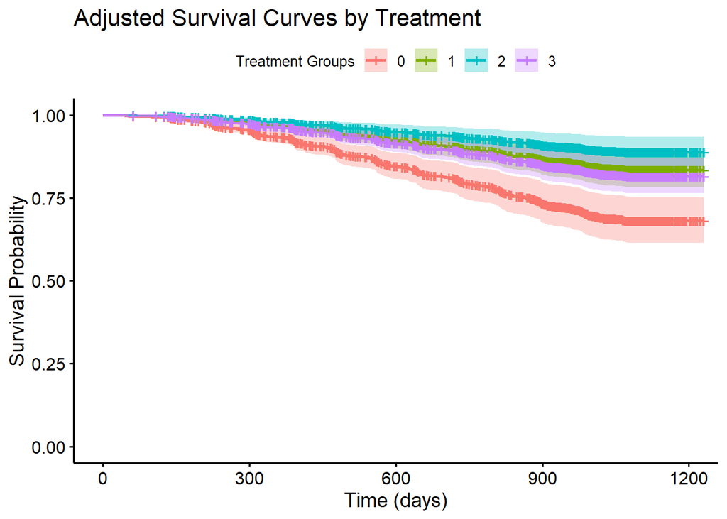

```r
# Create survival curves adjusted for treatment
adjusted_fit <- survfit(cox_model, newdata = data.frame(
  trt = levels(data$trt),  # Use all levels of the treatment factor
  karnof = mean(data$karnof, na.rm = TRUE),  # Mean age as an example
  cd40 = mean(data$cd40, na.rm = TRUE),
  str2 = levels(data$str2)[1],  # Reference gender level
  symptom = levels(data$symptom)[1]  # Reference health status level
))

# Visualize the adjusted survival curves
ggsurvplot(adjusted_fit,
           data = data,
           legend.title = "Treatment Groups",
           legend.labs = levels(data$trt),  # Ensure this matches levels of 'trt'
           xlab = "Time (days)",
           ylab = "Survival Probability",
           title = "Adjusted Survival Curves by Treatment")
```

```r
cox.zph(cox_model)
```

```
##              chisq df       p
## trt          9.292  3 0.02566
## karnof       0.994  1 0.31875
## str2         0.067  1 0.79572
## symptom      1.636  1 0.20089
## cd40        13.246  1 0.00027
## trt:karnof  10.686  3 0.01355
## trt:str2     3.168  3 0.36644
## trt:symptom  0.840  3 0.83998
## trt:cd40    18.346  3 0.00037
## GLOBAL      36.678 19 0.00870
```

```r
# Categorize cd40 into meaningful groups (e.g., quartiles)
data$cd40_group <- cut(data$cd40,
                       breaks = quantile(data$cd40, probs = seq(0, 1, by = 0.25), na.rm = TRUE),
                       include.lowest = TRUE,
                       labels = c("Low", "Lower-Mid", "Upper-Mid", "High"))

# Check the distribution of the new groups
table(data$cd40_group)
```

```
##
##       Low Lower-Mid Upper-Mid      High
##       535       541       531       532
```

```r
# Fit a Cox model stratified by the grouped cd40 variable
cox_model_strat_grouped <- coxph(Surv(time, cid) ~ trt + age + gender + karnof + str2 + symptom +
                                 strata(cd40_group), data = data)

# Print the summary of the stratified model
summary(cox_model_strat_grouped)
```

```
## Call:
## coxph(formula = Surv(time, cid) ~ trt + age + gender + karnof +
##     str2 + symptom + strata(cd40_group), data = data)
##
##   n= 2139, number of events= 521
##
##               coef exp(coef)  se(coef)      z Pr(>|z|)
## trt1     -0.787936  0.454782  0.123981 -6.355 2.08e-10 ***
## trt2     -0.692293  0.500427  0.121651 -5.691 1.26e-08 ***
## trt3     -0.570950  0.564988  0.115844 -4.929 8.28e-07 ***
## age       0.008381  1.008416  0.005146  1.629 0.103407
## gender    0.174658  1.190839  0.126356  1.382 0.166889
## karnof   -0.018849  0.981328  0.006960 -2.708 0.006765 **
## str21     0.364255  1.439442  0.095995  3.795 0.000148 ***
## symptom1  0.433707  1.542966  0.102343  4.238 2.26e-05 ***
## ---
## Signif. codes:  0 '***' 0.001 '**' 0.01 '*' 0.05 '.' 0.1 ' ' 1
##
##          exp(coef) exp(-coef) lower .95 upper .95
## trt1        0.4548     2.1989    0.3567    0.5799
## trt2        0.5004     1.9983    0.3943    0.6352
## trt3        0.5650     1.7699    0.4502    0.7090
## age         1.0084     0.9917    0.9983    1.0186
## gender      1.1908     0.8397    0.9296    1.5255
## karnof      0.9813     1.0190    0.9680    0.9948
## str21       1.4394     0.6947    1.1926    1.7374
## symptom1    1.5430     0.6481    1.2625    1.8857
##
## Concordance= 0.639  (se = 0.012 )
## Likelihood ratio test= 104.7  on 8 df,   p=<2e-16
## Wald test            = 111.1  on 8 df,   p=<2e-16
## Score (logrank) test = 114.2  on 8 df,   p=<2e-16
```

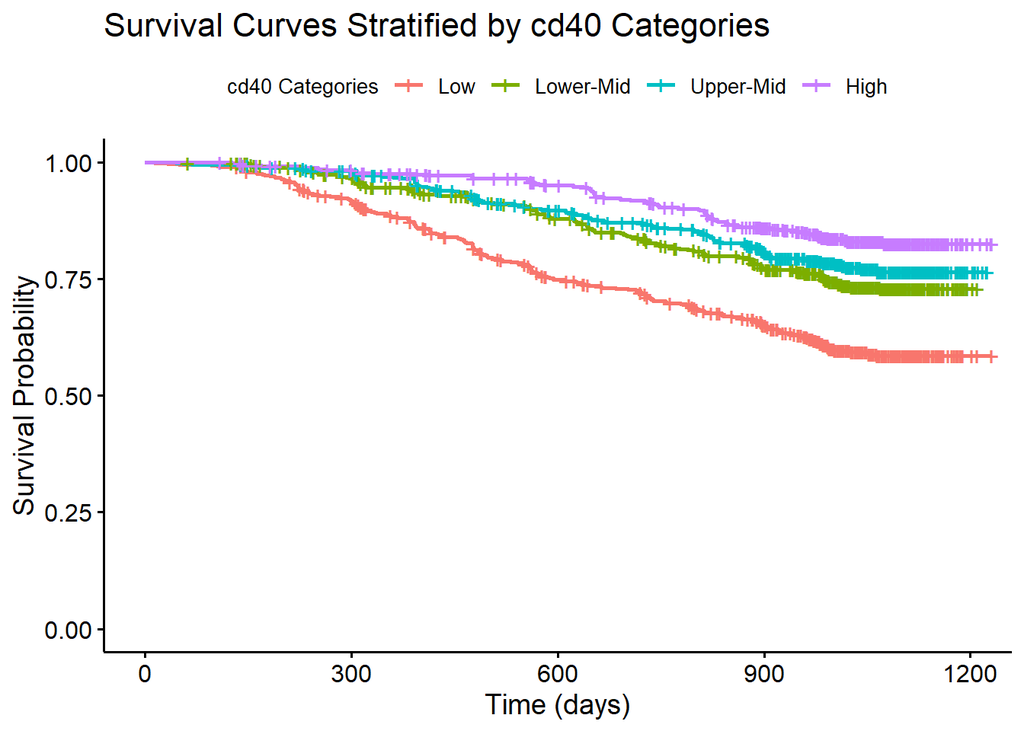

```r
# Generate survival curves for the grouped cd40 strata
adjusted_fit_grouped <- survfit(cox_model_strat_grouped)

# Visualize the survival curves
ggsurvplot(adjusted_fit_grouped,
           data = data,
           legend.title = "cd40 Categories",
           xlab = "Time (days)",
           ylab = "Survival Probability",
           title = "Survival Curves Stratified by cd40 Categories")
```

The survival curves stratified by CD40 categories (Low, Lower-Mid, Upper-Mid, High) show a clear trend where higher baseline CD40 levels are associated with better survival probabilities over time. Patients in the “Low” CD40 category exhibit the steepest decline in survival probability, indicating a higher risk of mortality compared to the other categories. Conversely, patients in the “High” CD40 category maintain the highest survival probability, reflecting a protective effect of higher baseline immune function.

Unlike Kaplan-Meier (KM) curves, which provide unadjusted survival probabilities based solely on CD40 categories, this stratified Cox proportional hazards model accounts for other covariates (e.g., treatment, age, symptoms, and Karnofsky score). This adjustment isolates the effects of these covariates while accounting for differences in baseline CD40 levels, offering a more nuanced understanding of survival outcomes. The stratified approach ensures that the strong influence of CD40 is appropriately addressed without confounding the effects of other variables, making it a more robust and informative analysis compared to using KM curves alone.

```r
cox.zph(cox_model_strat_grouped)
```

```
##            chisq df     p
## trt     10.64121  3 0.014
## age      0.83469  1 0.361
## gender   0.00647  1 0.936
## karnof   0.18116  1 0.670
## str2     0.02932  1 0.864
## symptom  0.43114  1 0.511
## GLOBAL  11.86747  8 0.157
```

stratifying cd40 into grouped categories effectively addressed the proportional hazards (PH) assumption violations for the variable.